# Modèle linéaire

Séance 1 - Régression linéaire simple

Florent Chuffart & Magali Richard

10 Janvier 2019

## Evaluation

- individuelle sur un jeu de données aprés 4 séances de cours
- data challenge à la fin des séances

## Pré-requis

- R https://cran.r-project.org
- RStudio https://www.rstudio.com

## Cours

- https://github.com/magrichard/cours_modlin_M1

# Organisation prévisionnelle

Séance 1 - 3h (10/01) Régression linéaire simple

Séance 2 - 3h (24/01) Régression linéaire multiple

Séance 3 - 3h (31/01) Anova 1 facteur / partie A

Séance 4 - 3h (14/02) Anova 1 facteur / partie B

Séance 5 - 3h (21/02) Anova 2 facteurs

Séance 6 - 3h (07/03) Anova multiple

Séance 7 - 3h (11/03) Anova facteurs emboités

Séance 8 - 3h (14/03) Ancova

# Plan séance 1

## Régression linéaire simple

1. Introduction
2. Présentation du modèle
3. Estimation (méthode des moindres carrés)
4. Décomposition de la variance
5. Test statistique et IC/IP
6. Résidus
7. Exemple détaillé sous R

## I. Introduction

**Objectif** : chercher une relation entre la variable observée $Y$ et la variable explicative $x$.

Les objectifs peuvent être multiples:

- approche exploratoire
- recherche de corrélation significative
- modèles de prédiction

Domaines d’application : chimie, astronomie, sismologie, économie, démographie, épidémiologie, géographie, écologie, géologie, physique, médecine…

Historiquement, le modèle linéaire a été développé par Fisher, avec applications en génétique et en agronomie.

## II. Présentation du modèle

Considérons $x$ et $Y$ deux variables. Y est expliquée (modélisée) par la variable explicative $x$.

**IMPORTANT** dans le cadre des modèles linéaire Y est quantitatives (Ex : taille, poids, age…).

Dans le cas de la regression linéaire simple, $Y$ est une **fonction affine** (ou **fonction linéaire**) de x.

$$Y = \beta_0 + \beta_1x$$

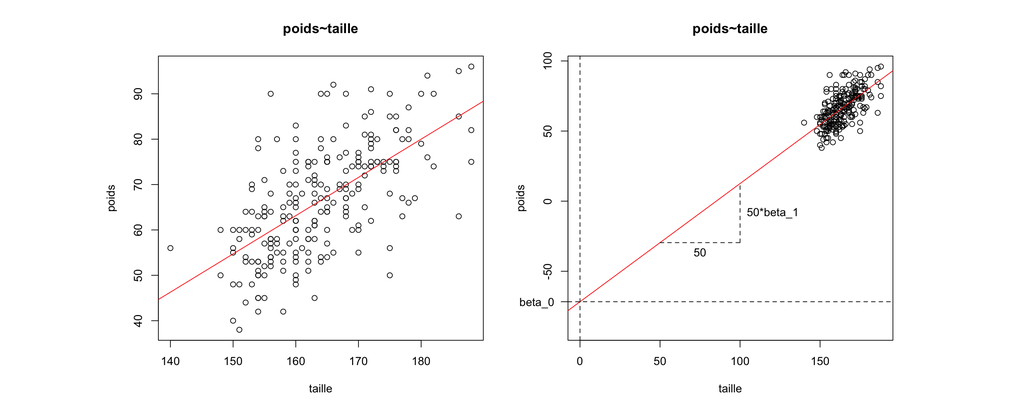

Les $n$ observations vont permettre de vérifier si la droite candidate est adéquate.

$x$ et $Y$ ne jouent pas un rôle identique :

- $x$ explique $Y$
- $x$ est une variable *indépendante* (ou *explicative*) et $Y$ est une variable *dépendante* (ou *expliquée*)

Remarques :

- On utilise un modèle linéaire Gaussien pour des observations pouvant être modélisées par une loi normales. Pour d’autres distributions (Poisson, Bernoulli…), on utilisera un modèle linéaire généralisé.
- La régression linéaire se caractérise par des variables explicatives **continues** ou quantitatives (Ex : poids~taille). L’ANOVA se caractérise par des variables explicatives **discrètes**, catégorielle, ou qualitatives (Ex : poids~sexe).

## II. Présentation du modèle

### Exemple d’une relation déterministe

$$Y = \beta_0 + \beta_1x$$

où $\beta_0$ et $\beta_1$ sont des réels fixés.

Par exemple la température $X$ en degrés Celsius, $Y$ en degrés Farenheit : $Y=32 + 9/5 X$.

Ici nous avons en identifiant : $\beta_0 = 32$ et $\beta_1 = 9/5$.

[figure not shown]

## II. Présentation du modèle

### Exemple d’une relation stochastique

Si ce cas déterministe n’est pas vérifié, il faut chercher la droite qui ajuste le mieux l’échantillon : **modèle linéaire non déterministe**.

$$Y = \beta_0 + \beta_1x + \epsilon$$

où $\beta_0$ et $\beta_1$ sont des réels fixes, mais inconnus, et $\epsilon$ une variable représentant le comportement individuel (résidus).

Modèle :
$$E(Y) = f(x) = \beta_0 + \beta_1 x$$

*Par exemple $x$ est la taille, $Y$ le poids, à une même taille, plusieurs poids peuvent correspondrent. Les données ne sont plus alignées.*

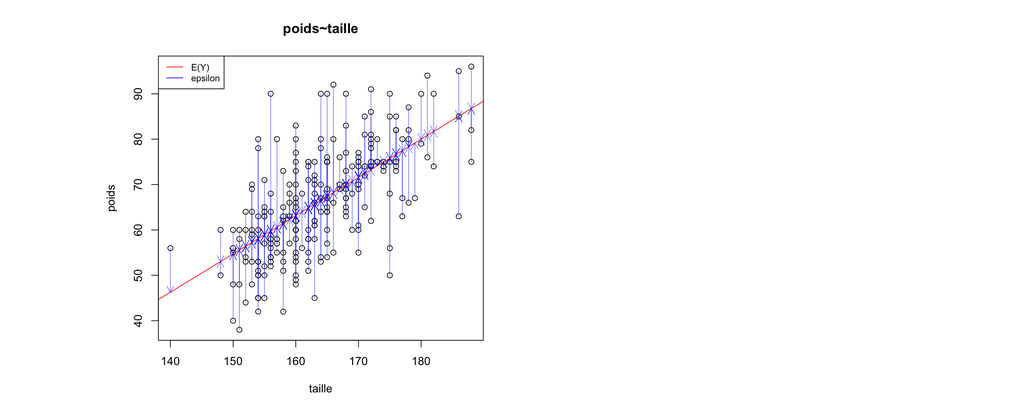

## II. Présentation du modèle

### Exemple

Base de données `data_nutri`

|  | sexe | situation | the | cafe | taille | poids | age | viande | poisson | fruit_crus | fruit_legume_cuits | chocol | matgras | sex |
| --- | --- | --- | --- | --- | --- | --- | --- | --- | --- | --- | --- | --- | --- | --- |
| 1 | Femme | Vit seul | 0 | 0 | 151 | 58 | 72 | 4/6 1 fois/sem | 2/3 fois/sem | &lt;1 fois/sem | 4/6 1 fois/sem | Tous les jours | Isio4 | Femme |
| 2 | Femme | Vit seul | 1 | 1 | 162 | 60 | 68 | Tous les jours | 1 fois/sem | Tous les jours | Tous les jours | &lt;1 fois/sem | Tournesol | Femme |
| 3 | Femme | Vit seul | 0 | 4 | 162 | 75 | 78 | 2/3 fois/sem | &lt;1 fois/sem | Tous les jours | 1 fois/sem | Tous les jours | Tournesol | Femme |
| 4 | Femme | Vit seul | 0 | 0 | 154 | 45 | 91 | Jamais | 4/6 1 fois/sem | 4/6 1 fois/sem | Jamais | 2/3 fois/sem | Margarine | Femme |
| 5 | Femme | Vit seul | 2 | 1 | 154 | 50 | 65 | Tous les jours | 2/3 fois/sem | Tous les jours | Tous les jours | 2/3 fois/sem | Margarine | Femme |
| 6 | Femme | Vit seul | 2 | 0 | 159 | 66 | 82 | 4/6 1 fois/sem | 1 fois/sem | Tous les jours | Tous les jours | &lt;1 fois/sem | Arachide | Femme |
| 7 | Femme | Vit seul | 2 | 0 | 160 | 66 | 74 | 2/3 fois/sem | 2/3 fois/sem | Tous les jours | Tous les jours | Tous les jours | Isio4 | Femme |
| 8 | Femme | Vit seul | 0 | 2 | 163 | 66 | 73 | 4/6 1 fois/sem | 1 fois/sem | Tous les jours | Tous les jours | &lt;1 fois/sem | Isio4 | Femme |
| 9 | Femme | Vit seul | 0 | 3 | 154 | 60 | 89 | 4/6 1 fois/sem | 2/3 fois/sem | Tous les jours | Tous les jours | Tous les jours | Isio4 | Femme |
| 10 | Femme | Vit seul | 0 | 2 | 160 | 77 | 87 | 1 fois/sem | 2/3 fois/sem | Tous les jours | 4/6 1 fois/sem | Jamais | Arachide | Femme |

[output cut: 216 more lines]

## II. Présentation du modèle

**Exemple** : représentation des données *poids~tailles*. **Question** : comment définir la droite de regression ?

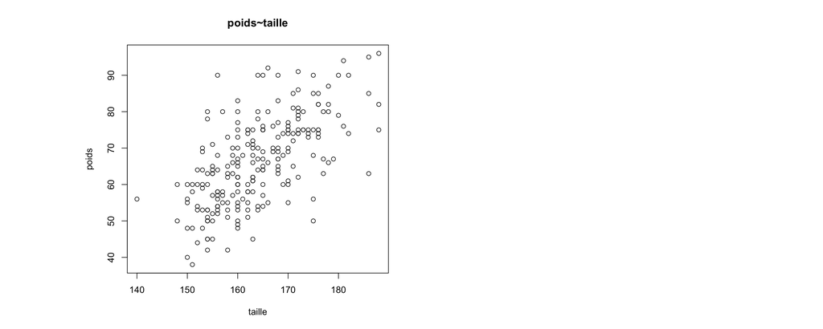

## III. Estimation - Méthode des moindres carrés

### Droite de regression

En analyse de régression linéaire, pour un individu $i$ :

- $x_i$ est fixé
- $Y_i$ est aléatoire
- la composante aléatoire de $Y_i$ est le $ε_i$ correspondant

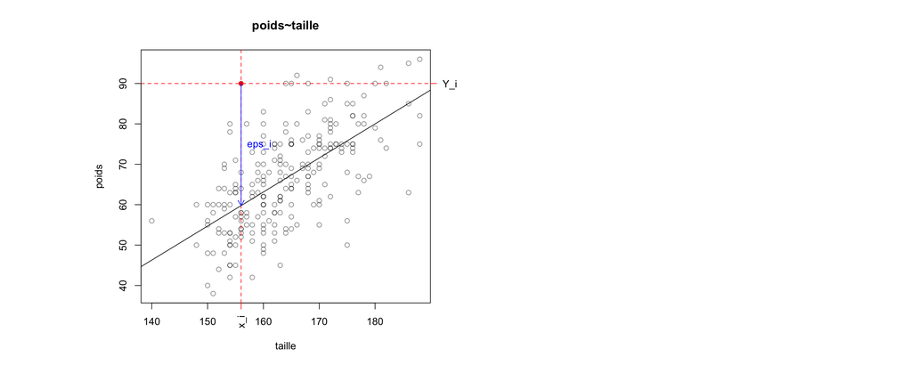

## III. Estimation - Méthode des moindres carrés

### Droite de regression

Pour l’instant, la droite de régression est inconnue. Tout le problème est d’estimer $\beta_0$ et $\beta_1$ à partir d’un échantillon de données.

On essaie de déterminer la **droite de regression** qui approche le mieux les données:
$$\widehat{Y}(x) = \widehat{\beta}_0 + \widehat{\beta}_1x$$

Avec $\widehat{Y}(x)$ un estimateur de la moyenne théorique $\mu_Y(x)$ ($\widehat{Y}(x)$ correspond à la moyenne de $Y$ mésurée sur tous les individus pour lesquels $x$ prend une valeur donnée).

$\mu_Y(x)$ n’est ni observable, ni calculable (il faudrait alors recenser **tous** les individus de la population).

*Remarque* : la moyenne empirique de $Y$, définie par $\overline{Y}_n(x) = \frac{1}{n}\sum^n_{i=1}Y_i(x)$ est un autre estimateur de $\mu_Y(x)$ . Si le modèle est bon, $\widehat{Y}(x)$ est plus précis que $\overline{Y}_n(x)$

## III. Estimation - Méthode des moindres carrés

### Droite de regression, intutition des moindres carrés

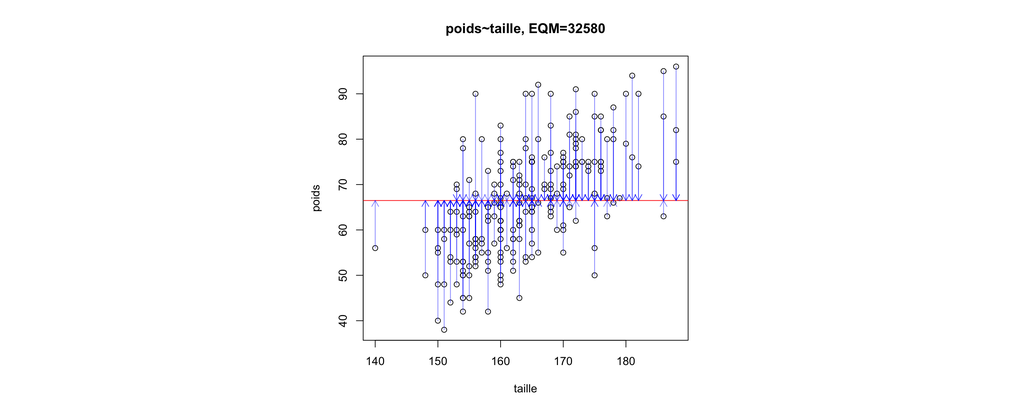

```r
layout(matrix(1, 1, byrow=TRUE), respect=TRUE)
beta_0 = mean(d$poids)
beta_1 = 0
res =  d$poids - (beta_0 + beta_1*d$taille)
eqm = sum(res^2)
plot(d$taille, d$poids, main=paste0("poids~taille, EQM=", round(eqm)), ylab="poids", xlab="taille")
abline(a=beta_0, b=beta_1, col=2) # /!\ y = b.x + a
suppressWarnings(arrows(d$taille, d$poids, d$taille, d$poids-res, length=0.1, col=adjustcolor(4, alpha.f=0.5)))
```

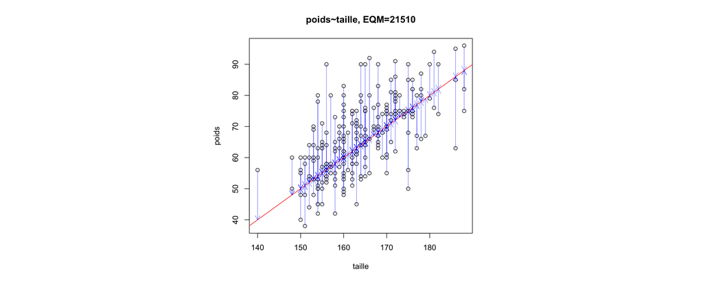

```r
beta_0 = -100
beta_1 = 1
res =  d$poids - (beta_0 + beta_1*d$taille)
eqm = sum(res^2)
plot(d$taille, d$poids, main=paste0("poids~taille, EQM=", round(eqm)), ylab="poids", xlab="taille")
abline(a=beta_0, b=beta_1, col=2) # /!\ y = b.x + a
suppressWarnings(arrows(d$taille, d$poids, d$taille, d$poids-res, length=0.1, col=adjustcolor(4, alpha.f=0.5)))
```

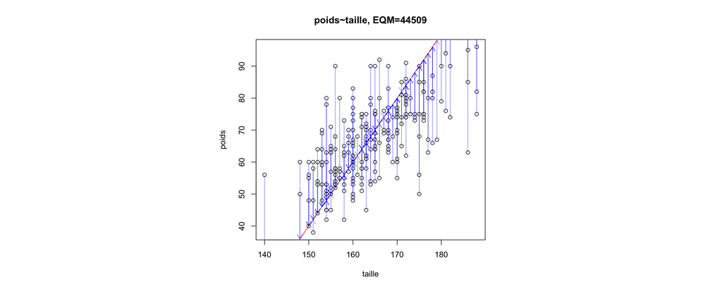

```r
beta_0 = -260
beta_1 = 2
res =  d$poids - (beta_0 + beta_1*d$taille)
eqm = sum(res^2)
plot(d$taille, d$poids, main=paste0("poids~taille, EQM=", round(eqm)), ylab="poids", xlab="taille")
abline(a=beta_0, b=beta_1, col=2) # /!\ y = b.x + a
suppressWarnings(arrows(d$taille, d$poids, d$taille, d$poids-res, length=0.1, col=adjustcolor(4, alpha.f=0.5)))
```

## III. Estimation - Méthode des moindres carrés

### Droite de regression, intutition des moindres carrés

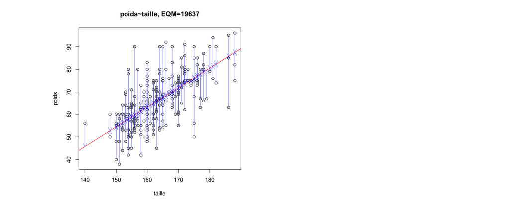

```r
layout(matrix(1:2, 1, byrow=TRUE), respect=TRUE)
results = list()
for(beta_0 in 0:-260) {
  for(beta_1 in seq(0,2, length.out=70)) {
    res =  d$poids - (beta_0 + beta_1*d$taille)
    eqm = sum(res^2)
    results[[length(results)+1]] = c(beta_0=beta_0, beta_1=beta_1, eqm=eqm)
  }
}
results = as.data.frame(do.call(rbind, results))
min(results$eqm)
r = results[results$eqm==min(results$eqm),]
beta_0 = r[["beta_0"]]
beta_1 = r[["beta_1"]]
res =  d$poids - (beta_0 + beta_1*d$taille)
eqm = sum(res^2)
plot(d$taille, d$poids, main=paste0("poids~taille, EQM=", round(eqm)), ylab="poids", xlab="taille")
abline(a=beta_0, b=beta_1, col=2) # /!\ y = b.x + a
suppressWarnings(arrows(d$taille, d$poids, d$taille, d$poids-res, length=0.1, col=adjustcolor(4, alpha.f=0.5)))
```

## III. Estimation - Méthode des moindres carrés

### Estimation et résidus

Lorsque $x = x_i$, alors $\widehat{Y}(x_i) = \widehat{Y}_i$ , c’est-à-dire :

$$\widehat{Y}_i=\widehat{\beta}_0+ \widehat{\beta}_1x_i$$
$\widehat{Y}_i$ est appelée la valeur estimée par le modèle.

Les quantités inobservables :
$$\epsilon_i = Y_i - \beta_0 - \beta_1x_i$$
sont estimées par les quantités observables :
$$e_i= Y-\widehat{Y}_i$$

- Les quantités $ei$ sont appelées les **résidus du modèle**.
- La plupart des méthodes d’estimation : estimer la droite de régression par une droite qui minimise une fonction de résidus.
- La plus connue : **la méthode des moindres carrés ordinaires (MCO)**.

## III. Estimation - Méthode des moindres carrés

### Méthode

**Objectif** : Définir des estimateurs qui minimisent la somme des carrés des résidus (ou **erreur quadratique moyenne** EQM).

Les estimateurs sont donc les coordonnées du minimum de la fonction à deux variables :

$$EQM(\beta_0, \beta_1) = \sum^{n}_{i=1} e^2_i = \sum^{n}_{i=1} (Y_i - \widehat{Y}_i)^2 = \sum^{n}_{i=1} (Y_i - \widehat\beta_0 - \widehat\beta_1x_i)^2$$

Cette fonction est appelée la **fonction objectif**.

## III. Estimation - Méthode des moindres carrés

### Méthode

Les estimateurs correspondent aux valeurs annulant les dérivées partielles de cette fonction :

$$\frac{\delta EQM(\beta_0, \beta_1)}{\delta \beta_0} = -2 \sum (Y_i - \beta_0 - \beta_1x_i)$$
$$\frac{\delta EQM(\beta_0, \beta_1)}{\delta \beta_1} = -2 \sum x_i (Y_i - \beta_0 - \beta_1x_i)$$

Les estimateurs $(\widehat\beta_0^{MCO},\widehat\beta_1^{MCO})$ sont les solutions du système d’équation:
$$\Bigg\{
\begin{align}
-2 \sum (Y_i - \beta_0 - \beta_1x_i) = 0 \\
-2 \sum x_i (Y_i - \beta_0 - \beta_1x_i) = 0
\end{align}$$

## III. Estimation - Méthode des moindres carrés

### Démonstration

Soient les equations suivantes:

$$(1) \sum{Y}_i = n\widehat\beta_0 + \widehat\beta_1 \sum{x_i}$$

$$(2) \sum{x_iY_i} = \widehat\beta_0 \sum{x_i} + \widehat\beta_1 \sum{x^2_i}$$
On utilise les notations usuelles des moyennes empiriques
$$\overline{x}_n = \frac{1}{n}\sum{x_i} ,\ \ \ \ \ \ \overline{Y}_n = \frac{1}{n}\sum{Y_i}$$

D’après (1):
$$\widehat\beta_0 = \overline{Y}_n - \widehat\beta_1 \overline{x}_n$$

D’après (2):

$$\begin{eqnarray}
\widehat\beta_1 \sum{x^2_i} & = & \sum{x_iY_i} - \widehat\beta_0 \overline{x}_n \\
& = & \sum{x_iY_i} - n\overline{x}_n\overline{Y}_n + \widehat\beta_1 (\overline{x}_n)^2
\end{eqnarray}$$

Ainsi
$$\widehat\beta_1 = \frac{\sum{x_iY_i} - n\overline{x}_n\overline{Y}_n}{\sum{x_i^2} - n(\overline{x}_n)^2}$$

Et comme nous avons :

$$\begin{eqnarray}
\sum{(x_i-\overline{x}_n)(Y_i-\overline{Y}_n)} & = & \sum{x_iY_i} - n\overline{x}_n\overline{Y}_n \\
\sum{(x_i-\overline{x}_n)} & = & \sum{x_i^2} - n(\overline{x}_n)^2
\end{eqnarray}$$

Nous obtenons:
$$\widehat\beta_1 = \frac{\sum{(x_i-\overline{x}_n)(Y_i-\overline{Y}_n)}}{\sum{(x_i-\overline{x}_n)}}$$

Dans la pratique, nous calculons $\widehat\beta_1$ puis $\widehat\beta_0$.

Nous obtenons ainsi une estimation de la droite de régression, appelée la droite des moindres carrés ordinaires:

$$\widehat{Y}(x) = \widehat\beta_0 + \widehat\beta_1x$$

## III. Estimation - Méthode des moindres carrés

### Exemple

$\widehat\beta_0$ correspond à l’ordonnée à l’origine. Ce paramètre n’est pas toujours interprétable (il dépend de la signifaction de $X$ et du fait que $X$ soit centré ou non).

$\widehat\beta_1$ correspond à la pente.

Attention, la technique des MCO crée des estimateurs sensibles aux valeurs atypiques.

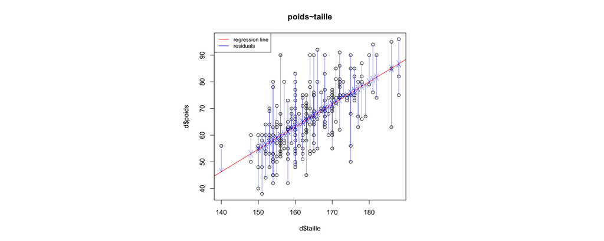

## IV. Décomposition de la variance

### Variation expliquée et inexpliquée

La variation de $Y$ vient du fait de sa dépendance à la variable explicative $X$. C’est la **variation expliquée par le modèle**.

Dans l’exemple « taille-poids », nous avons remarqué que lorsque nous mesurons $Y$ avec une même valeur de $X$, nous observons une certaine variation sur $Y$. C’est la **variation inexpliquée par le modèle**.

Variation totale de Y = Variation expliquée par le modèle + Variation inexpliquée par le modèle

Soit
$$(Y_i - \overline{Y}_n) = (\widehat{Y}_i - \overline{Y}_n) + (Y_i - \widehat{Y}_i)$$
avec $(\widehat{Y}_i - \overline{Y}_n)$ la différence expliquée par le modèle et $(Y_i - \widehat{Y}_i)$ la différence inexpliquée (ou résidu).

## IV. Décomposition de la variance

### Interêt des moindres carrés

La méthode des moindres carrés conserve la décomposition (en variance expliquée et résiduelle) en considérenat la somme des carrés de ces différences:

$$\sum(Y_i - \overline{Y}_n)^2 = \sum(\widehat{Y}_i - \overline{Y}_n)^2 + \sum(Y_i - \widehat{Y}_i)^2$$
Soit
$$SC_{tot} = SC_{reg} + SC_{res}$$

Avec $SC_{tot}$ la somme des carrés totale, $SC_{reg}$ la somme des carrés due à la régression et $SC_{res}$ la somme des carrés des résidus.

## IV. Décomposition de la variance

### Coefficient de determination $R^2$

La mesure du pourcentage de la variation totale expliquée par le modèle se fait par le **coefficient de détermination**.

$$R^2 = \frac{SC_{reg}}{SC_{tot}}$$

- $R^2$ est compris entre 0 et 1.
- $R^2 = 1$ : cas où les données sont parfaitement alignées (comme c’est le cas pour un modèle déterministe).
- $R^2 = 0$ :cas où la variation de $Y$ n’est pas due à la variation de $X$. Les données ne sont pas du tout alignées.
- Plus $R^2$ est proche de 1, plus les données sont alignées sur la droite de régression.

## V. Test statistique et IC/IP

### Hypothèses fondamentales

Il est important de noter que la construction du modèle de régression et l’estimation des paramètres par MCO ne fait pas appel aux hypothèses de distribution

Les hypothèses de distribution sont essentielles lorsqu’il s’agit de construire des tests et des intervalles de confiance et de prédiction.

Hypothèses fondamentales:

- Les observations sont indépendantes
- La variance des erreurs est constante $\sigma^2$
- La loi des erreurs est une loi normale $\mathcal{N}(0, \sigma^2)$

## V. Test statistique et IC/IP

### Test des paramètres

On se pose la question de l’effet de la variable $x$ :

$\mathcal{H}_0 : {\beta_1 = 0}$ contre $\mathcal{H}_1 : {\beta_1 \neq 0}$

**Conditions d’applications du test** : Les variables aléatoire $\epsilon_i$ sont indépendantes et suivent la loi normale centrée et de variance $\sigma^2$.

*Test d’ajustement des résidus à une gaussienne* :

- Test de shapiro
- Test de Kolmogoroff-Smirnoff (fondé sur les fonctions de répartition). Ce test à une tendance à rejeter l’hypothèse de normalité.
- Test du QQ plot

## V. Test statistique et IC/IP

### Test des paramètres

**Statistique du test** : Si l’hypothese nulle $\mathcal{H}_0$ est vérifiée, alors la variable aléatoire $\mathcal{T}_{\widehat\beta_1,n-2} = \frac{\widehat\beta_1-0}{s_{\widehat\beta_1}}$ suit la loi de Student $\mathcal{T}(n-2)$

**Décision et conclusion du test**: La valeur critique du test, notée $c_\alpha$ est lue dans une table de la loi de Student.

- Si la valeur absolue de la valeur de la statistique calculée sur l’echantillon, notée $\mathcal{T}_{\widehat\beta_1,n-2}(obs)$ est supérieure ou égale à $c_\alpha$, alors le test est significatif. Vous rejetez $\mathcal{H}_0$ et vous décidez que $\mathcal{H}_1$ est vraie avec un risque d’erreur de première espèce $\alpha$.
- Si la valeur absolue de la valeur de la statistique calculée sur l’echantillon, notée $\mathcal{T}_{\widehat\beta_1,n-2}(obs)$ est strictement inférieure à $c_\alpha$, alors le test n’est pas significatif. Vous conservez $\mathcal{H}_0$ avec un risque d’erreur de deuxième espèce $\beta$ à évaluer.

## V. Test et IC

### Notations

-$\widehat\sigma^2_n$ : la variance résiduelle -$s^2_Y$ : la variance de l’échantillon des $Y_i$ -$s^2_x$ : la variance de l’échantillon des $x_i$ -$s^2_{\beta_1}$ : La variance de l’estimateur $\widehat\beta_1$ -$s^2_{\beta_0}$ : La variance de l’estimateur $\widehat\beta_0$

L’estimation de la variance $\sigma^2$ peut se faire La variance des résidus est estimée par :
$$\widehat\sigma^2_n = \frac{1}{n-2}\sum^n_{i=1} (Y_i - \widehat\beta_0 - \widehat\beta_1x_i)^2 = \frac{n}{n-2}s^2_Y(1-R^2)$$

Avec $s^2_Y = \frac{1}{n}(\sum^n_{i=1}Y_i^2)-(\overline{Y}_n)^2$ la variance de l’échantillon des $Y_i$ et $\overline{Y}_n$ la moyenne des $Y_i$.

$$s^2_{\beta_1} = \frac{\widehat\sigma^2_n}{ns^2_x}$$

$$s^2_{\beta_0} = \widehat\sigma^2_n\Big(\frac{1}{n}+\frac{\overline{x}_n}{ns^2_x}\Big)$$

## V. Test et IC

### Intervalle de confiance

On peut construire les intervalles de confiance suivants

$$IC_{1-\alpha}(\widehat\beta_1) = \Big]\widehat\beta_1 - t_{n-2;1-\alpha/2}*s_{\beta_1}; \widehat\beta_1 + t_{n-2;1-\alpha/2}*s_{\beta_1}\Big[$$

$$IC_{1-\alpha}(\widehat\beta_0 = \Big]\widehat\beta_0 - t_{n-2;1-\alpha/2}*s_{\beta_0}; \widehat\beta_0 + t_{n-2;1-\alpha/2}*s_{\beta_0}\Big[$$

Ainsi que l’intervalle de prédiction d’une valeur moyenne de $Y$, sachant que $x = x_0$.

L’estimation ponctuelle pour cette valeur de $x_0$ est alors égale a $\widehat{Y}_0 = \widehat\beta_0 + \widehat\beta_1x_0$

$$IP_{1-\alpha}(Y) = \Big]\widehat{Y}_0 - t_{n-2;1-\alpha/2}\sqrt{\widehat\sigma^2_n\Big(\frac{1}{n}+\frac{(x_0-\overline{x}_n)^2}{(n-1)s^2_x}\Big)}; \widehat{Y}_0 + t_{n-2;1-\alpha/2}*\sqrt{\widehat\sigma^2_n\Big(\frac{1}{n}+\frac{(x_0-\overline{x}_n)^2}{(n-1)s^2_x}\Big)}\Big[$$

## VI. Résidus

### Motivation et définition

Hypothèses fondamentales:

- $\epsilon_i$ sont gaussien $\mathcal{N}(0,\sigma^2)$
- $\epsilon_i$ sont indépendants
- $\sigma^2$ est constante (homoscédasticité)

Les valeurs exactes des résidus sont inconnues mais on les estimes par:

$$\widehat\epsilon_i = Y_i - (\widehat\beta_0 + \widehat\beta_1x_i)$$

On introduit le coefficient $h_{ij}$ tel que:

$$h_{ij} = \frac{1}{n} + \frac{(x_i -\overline{x})^2}{\sum^n_{i=1}(x_i -\overline{x})^2}$$

## VI. Résidus

### Effet levier, distance de Cook

Le terme $h_{ij}$ représente le poids de l’observation $i$ sur sa propre estimation. On peut montrer que:
$$\widehat{Y_i} = h_{ij}Y_i + \sum_{j\neq i}h_{ij}Y_j$$
$$h_{ij} = \frac{1}{n} + \frac{(x_i - \overline{x})(x_j - \overline{x}) }{\sum^n_{h=1}(x_h-\overline{x})^2}$$

Si $h_{ij}$ est grand ($\geq \frac{1}{2}$), alors le point $i$ est un point levier (point atypique).

La distance de Cook est utilisée pour mesurer l’influence de l’observation $i$ sur l’estimation:

$$D_i= \frac{\sum^n_{j=1}(\widehat{Y}_{(i)j}-\widehat{Y}_j)^2}{2\widehat\sigma^2} = \frac{h_{ij}}{2(1-h_{ij})}r^2_i$$

## Notes

Ce cours s’inspire des références suivantes:

- Frédéric Bertrand & Myriam Maumy-Bertrand
- Franck Picard
- Irenne Ganaz